#### Acidification

##### Aragonite saturation

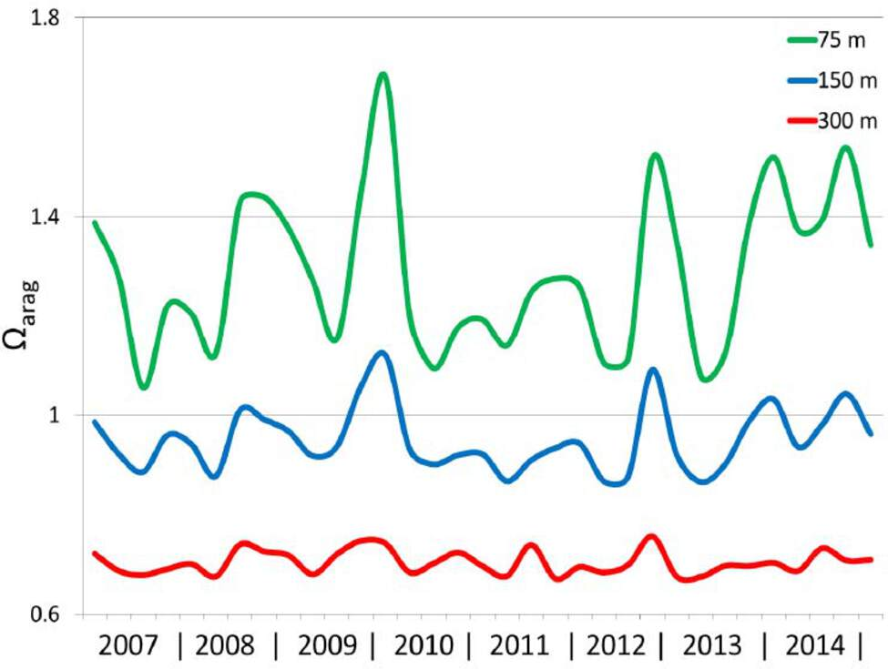

**Figure App.E.10.29.**. A figure showing the concentration of the mineral [aragonite](https://github.com/marinebon/cinms/blob/master/modals/_glossary.md) (a form of calcium carbonate) at different depths at Anacapa Island from 2007 - 2014.

**Click for Details**

[Aragonite saturations](https://github.com/marinebon/cinms/blob/master/modals/_glossary.md) are shown at 75 meters (m) (green), 150 m (blue) and 300 m (red) at Anacapa Island. As pH of seawater decreases (e.g., from the deposition of atmospheric CO2), the saturation state of aragonite (Ωarg) decreases. Aragonite undersaturation (Ωarg < 1) favors dissolution over calcification, making it harder for organisms to make and maintain their shells or skeletons in the case of corals. In coastal upwelling zones, such as the California Current, the aragonite saturation state and depth are variable and shallow, respectively. With ocean acidification, aragonite saturation depths have shoaled over the past three decades and are now typically around 200 m in the California Current (Turi et al. 2016). At the local scale at Anacapa Island, the aragonite saturation depth has hovered around 130 m over the past eight years. As strong of a shoaling trend as at the California Current scale has not been seen. Instead, he usual seasonal variation but relatively stable aragonite saturation states over time (no trend), particularly in deep water, have been seen. Figure: Etnoyer et al. 2015